# 09_analysis

## Ensemble Model Approach with Optimized Classifiers

The ensemble model uses soft voting to aggregate the predicted probabilities from each individual model, aiming to improve the overall predictive performance by leveraging the strengths of each classifier. The ensemble model combines the predictions from the CatBoost Classifier, Gradient Boosting Classifier, and LightGBM Classifier to create a more accurate and robust final model.

```python
# Suppress output during model operations
@contextmanager
def suppress_output():
    original_stdout = sys.stdout
    original_stderr = sys.stderr
    try:
        sys.stdout = open(os.devnull, 'w')
        sys.stderr = open(os.devnull, 'w')
        yield
    finally:
        sys.stdout.close()
        sys.stdout = original_stdout
        sys.stderr = original_stderr


# Suppress LightGBM output
lgbm_best.set_params(verbosity=-1)
gb_best.set_params
cb_best.set_params

# Define the VotingClassifier with the configured base models
ensemble_df = VotingClassifier(
    estimators=[('gb', gb_best),
                ('cb', cb_best),
                ('lgbm', lgbm_best)],
    voting='soft'
)

# Fit and evaluate the ensemble model with suppressed output
with suppress_output():
    # Train the ensemble
    ensemble_df.fit(X_final_train, y_final_train)

    # Compute learning curve
    train_sizes, train_scores, val_scores = learning_curve(
        ensemble_df, X_final_train, y_final_train,
        cv=5, scoring='f1', n_jobs=-1,
        train_sizes=np.linspace(0.1, 1.0, 5)
    )

# Fit and evaluate the ensemble model with suppressed output
with suppress_output():
    # Train the ensemble
    ensemble_df.fit(X_final_train, y_final_train)
```

## Compare Train and Validation Performance

This comparison helps you understand how well the ensemble model generalizes to unseen data. I will evaluate the ensemble model on the validation set. Also to check for overfitting that might have occurred during training.

### Validation Set Evaluation

```
Ensemble Model Performance on Validation Set:
Accuracy on Validation Set: 0.8125359401955147
F1 Score on Validation Set: 0.8206820682068208
ROC AUC Score on Validation Set: 0.902338396905771
Classification Report (Validation Set):
               precision    recall  f1-score   support

       False       0.84      0.77      0.80       863
        True       0.79      0.85      0.82       876

    accuracy                           0.81      1739
   macro avg       0.81      0.81      0.81      1739
weighted avg       0.81      0.81      0.81      1739
```

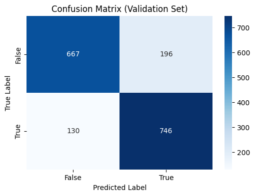

```python
# Generate predictions for the validation set
y_pred_ensemble_val = ensemble_df.predict(
    X_val_processed)
y_pred_proba_ensemble_val = ensemble_df.predict_proba(
    X_val_processed)[:, 1]

# Print ensemble performance on the validation set
print("\nEnsemble Model Performance on Validation Set:")
print("Accuracy on Validation Set:", accuracy_score(
    y_val, y_pred_ensemble_val))
print("F1 Score on Validation Set:", f1_score(
    y_val, y_pred_ensemble_val))
print("ROC AUC Score on Validation Set:", roc_auc_score(
    y_val, y_pred_proba_ensemble_val))
print("Classification Report (Validation Set):\n", classification_report(
    y_val, y_pred_ensemble_val))

# Generate and display the confusion matrix
conf_matrix = confusion_matrix(y_val, y_pred_ensemble_val)

# Plot confusion matrix
plt.figure(figsize=(6, 4))
sns.heatmap(conf_matrix, annot=True, fmt="d", cmap="Blues",
            xticklabels=['False', 'True'],
            yticklabels=['False', 'True'])
plt.xlabel("Predicted Label")
plt.ylabel("True Label")
plt.title("Confusion Matrix (Validation Set)")
plt.show()
```

### Training Set Evaluation

By checking training performance, you can spot potential overfitting if the scores on the training set are substantially higher than on the validation set.

```
Ensemble Model Performance on Training Set:
Training Accuracy: 0.8275812482024734
Training F1 Score: 0.833680122069635
Training ROC AUC Score: 0.9179100934212069

Classification Report (Training Set):
              precision    recall  f1-score   support

       False       0.85      0.80      0.82      3452
        True       0.81      0.86      0.83      3502

    accuracy                           0.83      6954
   macro avg       0.83      0.83      0.83      6954
weighted avg       0.83      0.83      0.83      6954
```

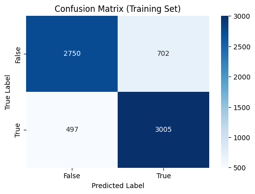

```python
# Evaluate ensemble on training set
y_pred_train = ensemble_df.predict(
    X_train_processed)
y_pred_proba_train = ensemble_df.predict_proba(
    X_train_processed)[:, 1]

# Print ensemble performance on the training set
print("Ensemble Model Performance on Training Set:")
print("Training Accuracy:", accuracy_score(
    y_train, y_pred_train))
print("Training F1 Score:", f1_score(
    y_train, y_pred_train))
print("Training ROC AUC Score:", roc_auc_score(
    y_train, y_pred_proba_train))

# Print classification report for training set
print("\nClassification Report (Training Set):")
print(classification_report(y_train, y_pred_train))

# Generate and display the confusion matrix
conf_matrix_train = confusion_matrix(y_train, y_pred_train)

# Plot confusion matrix for training set
plt.figure(figsize=(6, 4))
sns.heatmap(conf_matrix_train, annot=True, fmt="d", cmap="Blues",
            xticklabels=['False', 'True'],
            yticklabels=['False', 'True'])
plt.xlabel("Predicted Label")
plt.ylabel("True Label")
plt.title("Confusion Matrix (Training Set)")
plt.show()
```

## Cross-Validation Performance

```python
# Ensure ensemble_df is your VotingClassifier with soft voting
ensemble_df = VotingClassifier(
    estimators=[('gb', gb_best), ('cb', cb_best), ('lgbm', lgbm_best)],
    voting='soft'
)

# Perform cross-validation and calculate F1 scores
cv_scores = cross_val_score(ensemble_df,
                            X_final_train,
                            y_final_train,
                            cv=5, scoring='f1',
                            n_jobs=-1)
print("Cross-Validation F1 Scores:", cv_scores)
print("Mean Cross-Validation F1 Score:", cv_scores.mean())
print("Standard Deviation of Cross-Validation F1 Score:", cv_scores.std())
```

```
Cross-Validation F1 Scores: [0.80289532 0.80415755 0.8077135  0.8087493  0.79625551]
Mean Cross-Validation F1 Score: 0.8039542352677802
Standard Deviation of Cross-Validation F1 Score: 0.0044171880512989615
```

## Practicing AutoML: H2O.ai

The goal was not necessarily to achieve the best possible performance, but rather to gain familiarity with the capabilities and outputs of H2O’s AutoML framework.

```python
import h2o
from h2o.automl import H2OAutoML
from h2o.frame import H2OFrame
import pandas as pd

# Initialize the H2O server and suppress output
h2o.no_progress()
h2o.init()

# Use get_feature_names_out to get all generated column
preprocessor.fit(X_train)
feature_names = preprocessor.get_feature_names_out()

# Convert preprocessed data to DataFrame with the correct feature names
X_train_df = pd.DataFrame(X_train_processed, columns=feature_names)
X_val_df = pd.DataFrame(X_val_processed, columns=feature_names)

# Convert the processed DataFrames to H2O Frames
X_train_h2o = H2OFrame(X_train_df)
y_train_h2o = H2OFrame(y_train.to_frame(name="Transported"))
X_val_h2o = H2OFrame(X_val_df)

# Combine features and target into one frame for H2O
train_h2o = X_train_h2o.cbind(y_train_h2o)

# Define target and feature columns
target = 'Transported'
x = train_h2o.columns
x.remove(target)

# Initialize H2OAutoML
aml = H2OAutoML(max_runtime_secs=600,
                max_models=10,
                balance_classes=True,
                stopping_metric="AUC",
                seed=42)

# Run AutoML
aml.train(x=x, y=target, training_frame=train_h2o)

# Get predictions and leaderboard, using multi-threading for conversions
pred_val_h2o = aml.leader.predict(X_val_h2o)
pred_val_df = pred_val_h2o.as_data_frame(use_multi_thread=True)
leaderboard_df = aml.leaderboard.as_data_frame(use_multi_thread=True)

print("\nLeaderboard:")
print(leaderboard_df.to_string())
```

[output not shown]

[output not shown]

```
17:04:29.906: AutoML: XGBoost is not available; skipping it.


Leaderboard:
                                                   model_id       auc   logloss     aucpr  mean_per_class_error      rmse       mse
0      StackedEnsemble_AllModels_1_AutoML_1_20241110_170429  0.882434  0.425683  0.891425              0.202900  0.372636  0.138858
1   StackedEnsemble_BestOfFamily_1_AutoML_1_20241110_170429  0.882358  0.425922  0.891336              0.203953  0.372814  0.138991
2                            GBM_5_AutoML_1_20241110_170429  0.880660  0.436042  0.890327              0.207752  0.375080  0.140685
3                            GBM_2_AutoML_1_20241110_170429  0.879736  0.441515  0.888426              0.204329  0.376459  0.141721
4                            GBM_3_AutoML_1_20241110_170429  0.878689  0.436132  0.888385              0.204778  0.375829  0.141247
5               GBM_grid_1_AutoML_1_20241110_170429_model_1  0.878174  0.440057  0.889226              0.210661  0.376555  0.141793
6                            GBM_1_AutoML_1_20241110_170429  0.877494  0.439596  0.886572              0.209109  0.376602  0.141829
7                            GBM_4_AutoML_1_20241110_170429  0.875633  0.440228  0.885317              0.208075  0.378047  0.142920
8                   DeepLearning_1_AutoML_1_20241110_170429  0.873856  0.445169  0.880417              0.204005  0.381588  0.145610
9                            GLM_1_AutoML_1_20241110_170429  0.872114  0.444958  0.878515              0.208532  0.380792  0.145002
10                           XRT_1_AutoML_1_20241110_170429  0.870377  0.468953  0.878898              0.216933  0.388502  0.150934
11                           DRF_1_AutoML_1_20241110_170429  0.869122  0.482578  0.879354              0.207884  0.383078  0.146749
```

AutoML H2O Summary:

Overall, H2O AutoML’s stacked ensemble models provide the most robust performance, combining strengths from multiple algorithms to achieve higher accuracy and better confidence in predictions. These models are highly recommended for further evaluation and deployment, especially given their superior AUC and balanced class errors.